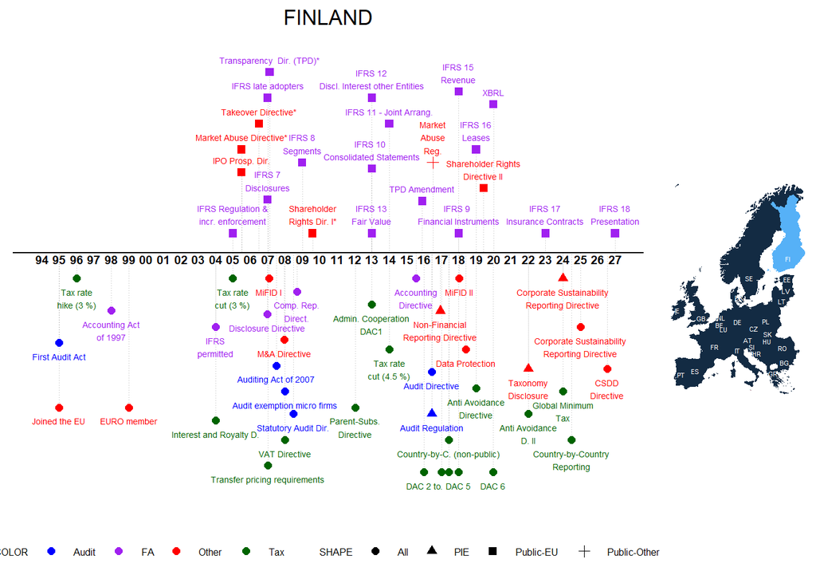

Notes: The graph depicts major regulatory changes that we identified via an extensive literature search, an online survey of mentioned authors, and other sources. Please note that the graph does not include all possible regulatory changes, e.g. minor revisions to local GAAP or tax rate changes below 3% are not included. The dates of EU Directives are based on the official transposition deadlines unless denoted with a *, in which case we included the entry-to-force date as identified in the literature. For more information, please go to [Labro and Pierk (2025)](https://link.springer.com/article/10.1007/s11142-025-09909-0). We kindly ask that you cite the paper if you use the information on this website in your research project. Do you have comments or see anything missing? Please email us!

## Regulations, Publications, Further Graphs

The tab ‘Regulations’ includes links to the regulations, gives short descriptions, and provides selective papers for further reading. If the regulation is a national transposition of an EU Directive, the link to the Directive is given. The tab ‘Number of Regulations’ shows graphically the number of regulations 8 years around the respective year (-4,-3,-2,-1,0,+1,+2,+3). The tab ‘Number of Categories” shows graphically the number of different categories 8 years around the respective year (-4,-3,-2,-1,0,+1,+2,+3). The tab ’Publications’ shows all publications that include the countries’ names and variations thereof in the title, abstract, or keywords. Similarly, the tab ‘SSRN’ shows papers of the SSRN Accouning Research Network that include the countries’ names and variations.

### Regulations

[output not shown]

[output cut: 52 more lines]

### Number of Regulations

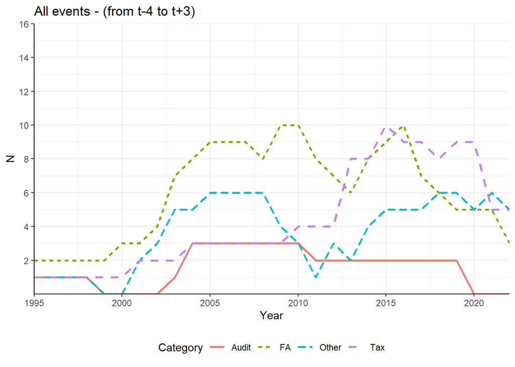

### Number of Categories

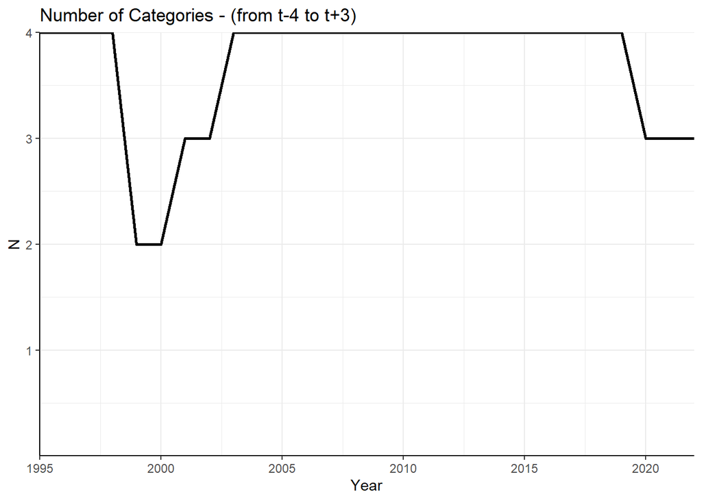

### Publications

|  | authors | title | year | journal |
| --- | --- | --- | --- | --- |
| 1 | Bonsón E., Lavorato D., Lamboglia R., Mancini D. | artificial intelligence activities and ethical approaches in leading listed companies in the european union | 2021 | International Journal of Accounting Information Systems |
| 2 | Haapamäki E. | an examination of comment letters concerning an increase in audit exemption thresholds. evidence from finland | 2021 | Accounting Forum |
| 3 | Kallio K.-M., Kallio T.J., Grossi G., Engblom J. | institutional logic and scholars' reactions to performance measurement in universities | 2021 | Accounting, Auditing and Accountability Journal |
| 4 | Mutiganda J.C., Järvinen J.T. | understanding political accountability in a strong structuration framework | 2021 | Accounting, Auditing and Accountability Journal |
| 5 | Paananen M., Rönkkö J., Zerni M., Hay D. | determinants of audit report modifications in finnish municipalities | 2021 | Journal of Accounting and Public Policy |
| 6 | Rajala T., Kokko P. | biased by design – the case of horizontal accountability in a hybrid organization | 2021 | Accounting, Auditing and Accountability Journal |
| 7 | Rautiainen A., Mättö T., Sippola K., Pellinen J.O. | accounting, microfoundations, hybridization and longitudinal conflict in a finnish health care organization | 2021 | Accounting, Auditing and Accountability Journal |
| 8 | Saastamoinen J., Savolainen H. | does a leopard change its spots? auditors and lawyers as valuation experts for minority shareholders in the judicial appraisal of private firms | 2021 | Journal of Business Finance and Accounting |
| 9 | Silvola H., Vinnari E. | the limits of institutional work: a field study on auditors' efforts to promote sustainability assurance in a trust society | 2021 | Accounting, Auditing and Accountability Journal |
| 10 | Fredriksson A., Kiran A., Niemi L. | reputation capital of directorships and demand for audit quality | 2020 | European Accounting Review |

[output cut: 83 more lines]

### SSRN

[output not shown]